# Resistance & recovery 4-sp communities: Analyze flow cytometry data

1st author

# Introduction

This notebook is for analyzing the time series flow cytometry data produced by 1st author (with help from research technician). It summarizes the findings for publication. This document is updated from `analyze_temp_serial_transfer_expt--28Oct24.Rmd`.

The goal is to understand how 15 different communities change during (resistance) and after (recovery) a heat pulse of different duration as compared to no heat pulse. There are 5 treatments: no heat (5 days serial transfer), 6h heat, 12h heat, 24h heat, and 48h heat. Each of these is setup with 5 technical replicates that was initially inoculated to about equal ratios (on Day 0).

The main questions the experiments are trying to answer: does inoculated community richness protect communities from heat? can we predict community composition based on monoculture traits of each of the 4 species? what is the relationship between resistance and recovery, and (how) does this change with heat pulse duration?

See the associated manuscript for more details. This notebook covers analysis of flow cytometry data as part of Experiment II in the manuscript. It needs to be run with `main_expt--OD_analysis.Rmd` because it relies on the OD data to confirm community extinction events.

## Summary of choices:

Based on the number of cells observed in true blank wells, I only include data from wells with >50 cells. Based on the flow cytometry data from Day 0 (which is estimated from the blanks in the OD data to have never experienced any contamination events), a misclassification rate of 1% is assumed. Contaminated replicates are defined as having a substantially higher % of a species that was not inoculated in that well (i.e., than expected from this misclassification rate). When a contaminated well was detected, all time points associated with that well were removed from the data.

# Load & Annotate Data

After loading the environment, I will load all of the flow cytometry cell count data and information about extinct wells from the OD data. Data is also annotated.

```r
library(tidyverse)
```

```r
library(readxl) # for importing data directly from Excel sheet
library(RColorBrewer) # for changing the colours of plots
library(ggbeeswarm) # for beeswarm plots
library(vegan) # to estimate diversity and for ordination (NMDS)
library(ggordiplots) # for ggplotting ellipses around treatment group centroids during ordination
library(chemodiv) # for estimating species richness
#library(lme4)  <-- not sure this is needed?
library(glmmTMB) # for fitting and trouble-shooting GLM's
library(DHARMa) # for plotting the residuals when using glmmTMB
library(rcompanion) # for r-squared estimates of GLM's
library(MuMIn) # for calculating AICc
library(performance) # for checking multicolinearity
library(effsize) # for post-hoc estimate of effect sizes
library(emmeans) # (ditto as above)
library(BSDA) # for pairwise t-tests to compare effect sizes between data subsets
#library(partitionBEFsp) # for paritioning the biodiversity effects
#library(ape) # for ordination ??
library(ggforce) # for plotting ellipses in ggplot

# print the complete info about packages and versions currently loaded in the environment:
```

```r
# set theme for all plots
fave_theme <- theme_light() + # see other options at https://ggplot2.tidyverse.org/reference/ggtheme.html
              theme(text = element_text(size=15), # larger text size for titles & axes
                    panel.grid.major = element_blank(), # remove major gridlines
                    panel.grid.minor = element_blank()) # remove minor gridlines
theme_set(fave_theme)

# define a palette for plotting the 4 species
species_4pal_alphabetical = palette.colors(8, palette = "R4")[c(3, 5, 7, 2)] #in alphabetical order
species_4pal_speed = palette.colors(8, palette = "R4")[c(7, 5, 3, 2)] #from fast to slow

# define a palette for plotting the 3 treatment days
trtmt_pal = brewer.pal(4, "Set2")[c(4, 3, 1)]

# define a palette for plotting the heat duration
control_to_48h_pal <- scale_colour_viridis_d(option = "plasma", begin=0.05, end = 0.9)

# define a palette for plotting the inoculated community richness
CommRich_pal <- scale_colour_viridis_d(option = "viridis", begin=0.2, end=0.95)

# define a function to find the mode of a vector. Credit to https://stackoverflow.com/questions/2547402/how-to-find-the-statistical-mode
Mode <- function(x) {
  ux <- unique(x)
  ux[which.max(tabulate(match(x, ux)))]
}
```

Load the cell counts data from the summary Excel files created by FCS Express. Then load the well volume data from the summary .csv files created by the Attune software.

```r
# a function to load the fluorescent counts data (from .xlsx files created by )
import_flow_counts <- function(file)
  return(as.data.frame(
          read_excel(path=file, sheet="FCS Express Report",
                    # replace the column names as follows:
                    col_names = c("Filename",
                                  "Gate1", "Count_grimontii",
                                  "Gate2", "Count_putida",
                                  "Gate3", "Count_protegens",
                                  "Gate4","Count_veronii")))
  )
# a function to load and parse the volume data
import_flow_volume <- function(file) {
  raw.csv <- read.csv(file)
  # keep the volume info and just enough data to identify the sample. Then remove resultant redundant rows
  vol_data <- raw.csv %>% select(Plate, Sample, Volume) %>% unique()
}

# a function to loop through the folders containing the data files, open the .xlsx and .csv files and combine their data
import_from_files <- function(dir_vector){
  # initiatize variables
  raw_counts <- raw_vols <- data.frame()
  # loop through each directory
  for(dir in dir_vector){
    # get all the file names
    files_v <- list.files(dir)

    # identify the excel files
    files_excel <- files_v[endsWith(files_v, ".xlsx")]
    # and loop through all of them to extract their data
    TMPraw_counts <- data.frame()
    for(val in files_excel){
      TMPraw_counts <- rbind(TMPraw_counts, import_flow_counts(paste0(dir, "/", val)))
    }

    # identify the csv files
    files_csv <- files_v[endsWith(files_v, ".csv")]
        # and loop through all of them to extract their data
    TMPraw_vols <- data.frame()
    for(val in files_csv){
      TMPraw_vols <- rbind(TMPraw_vols, import_flow_volume(paste0(dir, "/", val)))
    }

    # concatenate the data from counts and from vols
    raw_counts <- rbind(raw_counts, TMPraw_counts)
    raw_vols <- rbind(raw_vols, TMPraw_vols)
    rm(TMPraw_counts, TMPraw_vols)
  }
  return(list(raw_counts, raw_vols))
}

# get all of the raw data:
list_rawdata <- import_from_files(c("./raw_data/serial_transf--2July24", "./raw_data/serial_transf--8July24", "./raw_data/serial_transf--5Aug24", "./raw_data/serial_transf--19Aug24"))
```

Now we can process the data to create unique ID’s for each sample. This info needs to be parsed from the Filename column for the flow counts data (i.e., excel files) and from the Plate column for the flow volumes data (i.e., csv files).

```r
# start with flow counts data:
  # I got confused and now there are rows containing the column names. Get rid of those...
list_rawdata[[1]] <- list_rawdata[[1]][-grep("Filename", list_rawdata[[1]]$Filename),]
  # Day0 has a different pattern in the Filename column so let's process those rows first
Day0 <- list_rawdata[[1]][grep("Day0", list_rawdata[[1]]$Filename),] %>% separate_wider_regex(Filename,
                                                                                              c(Date="24-0\\d-\\d{2}", " Day", Day="\\d",
                                                                                                ".*dilution_", Well="\\w\\d+", "\\.acs compensated"))
  # Now process the Filename column for the other days
NOTday0 <- list_rawdata[[1]][-grep("Day0", list_rawdata[[1]]$Filename),] %>% separate_wider_regex(Filename,
                                                                                              c(Date="24-0\\d-\\d{2}", " Day", Day="\\d", " -- ",
                                                                                                Incubator="\\w+", "\\.plate", Plate="\\d",
                                                                                                ".*dilution_", Well="\\w\\d+", "\\.acs compensated"))
# Put the flow counts data back together into a single data.frame:
raw_Counts <- rbind(Day0 %>% mutate(Incubator=NA, Plate=0), # add in the 2 extra empty columns that are missing from Day0
                    NOTday0) %>% select(-Gate1, -Gate2, -Gate3, -Gate4)
rm(Day0, NOTday0)


# then do a similar thing for the volume data:
  # Day0 has a different pattern in the Plate column so let's process those rows first
Day0 <- list_rawdata[[2]][grep("Day0", list_rawdata[[2]]$Plate),] %>% separate_wider_regex(Plate,
                                                                                           c(Date="24-0\\d-\\d{2}", " Day", Day="\\d", ".*"))
  # Now process the Plate column for the other days
NOTday0 <- list_rawdata[[2]][-grep("Day0", list_rawdata[[2]]$Plate),] %>% separate_wider_regex(Plate,
                                                                                              c(Date="24-0\\d-\\d{2}", " Day", Day="\\d", " -- ",
                                                                                                Incubator="\\w+", "\\.plate", Plate="\\d"))
# Put the flow volumes data back together into a single data.frame:
raw_Vol <- rbind(Day0 %>% mutate(Incubator=NA, Plate=0), # add in the 2 extra empty columns that are missing from Day0
                 NOTday0) %>% rename(Well = Sample) # rename this column for consistency with the Counts data
rm(Day0, NOTday0)

# We can now combine the counts and volume data
  # here I need to use left join because we don't have volume data for Day 0 on 24-07-02 !!!!!!
raw_data <- left_join(raw_Counts, raw_Vol,
                      by=c("Date", "Day", "Well", "Incubator", "Plate"))
rm(raw_Counts, raw_Vol)


# add annotation specifying the Heat treatment and the Incubator
  # For 2July24: all samples were subjected to 6h of heat
  # For 8July24: samples in the Epoch plate reader are control (no heat)
  #              Samples in the H1 plate reader are 48h of heat
  # For 5Aug24: all samples were subjected to 12h of heat
  # For 19Aug24: all samples were subjected to 24h of heat
raw_data$Heat <- 0
raw_data$Heat[which(raw_data$Date == "24-07-02")] <- 6
raw_data$Heat[which(raw_data$Date == "24-07-08" & raw_data$Incubator == "H1")] <- 48
raw_data$Heat[which(raw_data$Date == "24-08-05")] <- 12
raw_data$Heat[which(raw_data$Date == "24-08-19")] <- 24

# change the variable classes for data analysis
raw_data$Count_grimontii <- as.numeric(raw_data$Count_grimontii)
raw_data$Count_putida <- as.numeric(raw_data$Count_putida)
raw_data$Count_protegens <- as.numeric(raw_data$Count_protegens)
raw_data$Count_veronii <- as.numeric(raw_data$Count_veronii)
```

Finally, we can annotate the data with the sample information for each well. Note that there are different plate layouts for Day0 (same for all dates) And the experiment from 24-07-02 uses a different layout as compared to the rest of the data (see the layout png file in the corresponding data subfolder). …But, also, I made other mistakes too so there’s modified layouts for that too! XP

```r
# the "Plate1" layout is used for all days >0 (except for 24-07-02)
layout.plate1 <- data.frame(Well = paste0(LETTERS[1:8], rep((2*1:6)-1, each=8)),
                            putida = c(0, 1, 1, 1, 0, 0, 0, 0,
                                       1, 0, 0, 0, 1, 1, 1, 0,
                                       0, 0, 1, 1, 1, 0, 1, 0,
                                       0, 0, 1, 1, 1, 0, 1, 0,
                                       1, 1, 1, 0, 1, 0, 0, 0,
                                           0, rep(0,6), 1),
                            protegens = c(0, 0, 0, 1, 0, 0, 1, 0,
                                          0, 1, 0, 0, 1, 0, 0, 1,
                                          1, 0, 1, 1, 0, 1, 1, 0,
                                          0, 0, 1, 0, 0, 1, 0, 1,
                                          1, 1, 0, 1, 1, 0, 1, 0,
                                              1, rep(0,6), 0),
                            grimontii =  c(0, 0, 1, 0, 0, 1, 0, 0,
                                           0, 0, 1, 0, 0, 1, 0, 1,
                                           0, 1, 1, 0, 1, 1, 1, 0,
                                           1, 0, 0, 1, 0, 1, 0, 0,
                                           1, 0, 1, 1, 1, 0, 0, 1,
                                               1, rep(0,6), 0),
                            veronii =    c(0, 1, 0, 0, 1, 0, 0, 0,
                                           0, 0, 0, 1, 0, 0, 1, 0,
                                           1, 1, 0, 1, 1, 1, 1, 0,
                                           0, 1, 0, 0, 1, 0, 0, 0,
                                           0, 1, 1, 1, 1, 0, 1, 1,
                                               0, rep(0,6), 0))

### CommRich = 0 corresponds to blanks, mistakes made on Day0 are removed altogether,
###     and CommRich = NA is used to indicate contamination.
# modified layout of plate1 specific for 24-07-02
layout.plate1_2Jul <- layout.plate1
layout.plate1_2Jul$putida[c(1,8, 41:48)]    <- c(0, 1, 1, 1, 1, 0, 1, 0, 0, 0)
layout.plate1_2Jul$protegens[c(1,8, 41:48)] <- c(1, 0, 1, 0, 0, 1, 0, 1, 0, 0)
layout.plate1_2Jul$grimontii[c(1,8, 41:48)] <- c(1, 0, 0, 1, 0, 1, 0, 0, 1, 0)
layout.plate1_2Jul$veronii[c(1,8, 41:48)]   <- c(0, 0, 0, 0, 1, 0, 0, 0, 0, 1)

# modified layout of plate1 specific for mistakes made on 24-07-08
  # column 4 of OD plate is swapped orientation
layout.plate1_8Jul <- layout.plate1
layout.plate1_8Jul$putida[25:32]    <- layout.plate1$putida[9:16]
layout.plate1_8Jul$protegens[25:32] <- layout.plate1$protegens[9:16]
layout.plate1_8Jul$grimontii[25:32] <- layout.plate1$grimontii[9:16]
layout.plate1_8Jul$veronii[25:32]   <- layout.plate1$veronii[9:16]

# add a column for community richness in all of the above df's
layout.plate1 <- layout.plate1 %>% mutate(CommRich = putida+protegens+grimontii+veronii , .keep="all")
layout.plate1_2Jul <- layout.plate1_2Jul %>% mutate(CommRich = putida+protegens+grimontii+veronii , .keep="all")
layout.plate1_8Jul <- layout.plate1_8Jul %>% mutate(CommRich = putida+protegens+grimontii+veronii , .keep="all")


# the "Plate2" layout
layout.plate2 <- data.frame(Well = paste0(LETTERS[1:8], rep((2*1:6)-1, each=8)),
                            putida = c(1, 1, 1, 0, 1, 0, 0, 0,
                                       1, 0, 1, 0, 0, 0, 1, 1,
                                       1, 0, 1, 0, 0, 0, 1, 1,
                                       1, 0, 0, 0, 1, 1, 1, 0,
                                           rep(0,7), 0,
                                       0, 1, 0, 1, 1, 1, 0, 0),
                            protegens = c(1, 0, 0, 1, 0, 1, 0, 0,
                                          0, 1, 1, 0, 1, 0, 1, 1,
                                          0, 1, 0, 1, 0, 0, 1, 0,
                                          1, 0, 1, 0, 1, 1, 0, 1,
                                              rep(0,7), 1,
                                          0, 1, 1, 0, 1, 1, 0, 0),
                            grimontii = c(0, 1, 0, 1, 0, 0, 1, 0,
                                          1, 1, 1, 0, 0, 1, 1, 0,
                                          0, 1, 0, 0, 1, 0, 0, 1,
                                          1, 0, 0, 1, 1, 0, 1, 1,
                                             rep(0,7), 0,
                                          0, 1, 1, 1, 0, 1, 1, 0),
                            veronii = c(0, 0, 1, 0, 0, 0, 0, 1,
                                        1, 1, 1, 0, 1, 1, 0, 1,
                                        1, 0, 0, 0, 0, 1, 0, 0,
                                        1, 0, 1, 1, 0, 1, 1, 1,
                                           rep(0,7), 1,
                                        0, 1, 1, 1, 1, 0, 1, 0))

# modified layout of plate2 specific for 24-07-02
layout.plate2_2Jul <- layout.plate2
layout.plate2_2Jul$putida[1:32]    <- layout.plate2$putida[c(9:32,41:47,40)]
layout.plate2_2Jul$protegens[1:32] <- layout.plate2$protegens[c(9:32,41:47,40)]
layout.plate2_2Jul$grimontii[1:32] <- layout.plate2$grimontii[c(9:32,41:47,40)]
layout.plate2_2Jul$veronii[1:32]   <- layout.plate2$veronii[c(9:32,41:47,40)]
layout.plate2_2Jul <- layout.plate2_2Jul[1:32,] # rest of flow plate 2 is empty

# modified layout of plate2 specific for mistakes made on 24-07-08 and 24-08-19
layout.plate2_8Jul19Aug <- layout.plate2[-(9:16),] # I screwed up column 8 of OD plate

# add a column for community richness in all of the above df's
layout.plate2 <- layout.plate2 %>% mutate(CommRich = putida+protegens+grimontii+veronii , .keep="all")
layout.plate2_2Jul <- layout.plate2_2Jul %>% mutate(CommRich = putida+protegens+grimontii+veronii , .keep="all")
layout.plate2_8Jul19Aug <- layout.plate2_8Jul19Aug %>% mutate(CommRich = putida+protegens+grimontii+veronii , .keep="all")

# the "Inocula" layout
layout.inocula <- data.frame(Well = paste0(LETTERS[1:8], rep((2*1:6)-1, each=8)),
                               putida = rep(c(1, 0, 0, 0, 1, 1, 1, 0,
                                              0, 0, 1, 1, 1, 0, 1, NA), times=3),
                            protegens = rep(c(0, 1, 0, 0, 1, 0, 0, 1,
                                              1, 0, 1, 1, 0, 1, 1, NA), times=3),
                            grimontii = rep(c(0, 0, 1, 0, 0, 1, 0, 1,
                                              0, 1, 1, 0, 1, 1, 1, NA), times=3),
                              veronii = rep(c(0, 0, 0, 1, 0, 0, 1, 0,
                                              1, 1, 0, 1, 1, 1, 1, NA), times=3)) %>%
                mutate(CommRich = putida+protegens+grimontii+veronii , .keep="all") %>%
                    filter(!is.na(CommRich))


# a function to annotate each data set with the indicated layout
  # this will KEEP well blanks!
annotate_samples <- function(layout, select_date, select_plate) {
  relevant_data <- raw_data %>% filter(Date==select_date, Plate==select_plate)

  # for Innoc, use inner_join to combine the flow data with its annotation
  if(select_plate == 0){
    output_df <- inner_join(layout, relevant_data, by="Well")
  }
  if(select_plate != 0) {
    output_df <- left_join(merge(layout, relevant_data %>% select(Day, Incubator, Heat) %>% distinct()),
                         relevant_data, by=c("Well", "Day", "Incubator", "Heat"))
    output_df$Date <- select_date
    output_df$Plate <- select_plate
  }

  return(output_df)
  rm(relevant_data, output_df)#, blank_annot, blank_data)
}

# now we can add the sample names for each one.
annotated.rawdata <- rbind(annotate_samples(layout = layout.inocula, select_date = "24-07-02", select_plate=0),
                  annotate_samples(layout = layout.plate1_2Jul, select_date = "24-07-02", select_plate=1),
                  annotate_samples(layout = layout.plate2_2Jul, select_date = "24-07-02", select_plate=2),
                  annotate_samples(layout = layout.inocula, select_date = "24-07-08", select_plate=0),
                  annotate_samples(layout = layout.plate1_8Jul, select_date = "24-07-08", select_plate=1),
                  annotate_samples(layout = layout.plate2_8Jul19Aug, select_date = "24-07-08", select_plate=2), ##
                  annotate_samples(layout = layout.inocula, select_date = "24-08-05", select_plate=0),
                  annotate_samples(layout = layout.plate1, select_date = "24-08-05", select_plate=1),
                  annotate_samples(layout = layout.plate2, select_date = "24-08-05", select_plate=2),
                  annotate_samples(layout = layout.inocula, select_date = "24-08-19", select_plate=0),
                  annotate_samples(layout = layout.plate1, select_date = "24-08-19", select_plate=1),
                  annotate_samples(layout = layout.plate2_8Jul19Aug, select_date = "24-08-19", select_plate=2))

# fixing other small mistakes in annotation:
  # Day1 of 24-07-02: sample A1 from plate 2 was loaded into sample A1 plate 1.
annotated.rawdata$CommRich[which(annotated.rawdata$Date=="24-07-02" & annotated.rawdata$Day=="1" &
                                   annotated.rawdata$Well=="A1" & annotated.rawdata$Plate=="1")] <- 3

annotated.rawdata$putida[which(annotated.rawdata$Date=="24-07-02" & annotated.rawdata$Day=="1" &
                                 annotated.rawdata$Well=="A1" & annotated.rawdata$Plate=="1")] <- 1

annotated.rawdata$protegens[which(annotated.rawdata$Date=="24-07-02" & annotated.rawdata$Day=="1" &
                                    annotated.rawdata$Well=="A1" & annotated.rawdata$Plate=="1")] <- 0

annotated.rawdata$grimontii[which(annotated.rawdata$Date=="24-07-02" & annotated.rawdata$Day=="1" &
                                    annotated.rawdata$Well=="A1" & annotated.rawdata$Plate=="1")] <- 1

annotated.rawdata$veronii[which(annotated.rawdata$Date=="24-07-02" & annotated.rawdata$Day=="1" &
                                  annotated.rawdata$Well=="A1" & annotated.rawdata$Plate=="1")] <- 1


# Annotate the treatments
annotated.rawdata$Heat_Day <- as.numeric(NA)
annotated.rawdata$Heat_Day[which(annotated.rawdata$Heat!=0 & annotated.rawdata$Day==1)] <- 1
annotated.rawdata$Heat_Day[which(annotated.rawdata$Heat>6 & annotated.rawdata$Day==2)] <- 2
annotated.rawdata$Heat_Day[which(annotated.rawdata$Heat==48 & annotated.rawdata$Day==3)] <- 3

annotated.rawdata$Recov_Day <- as.numeric(NA)
annotated.rawdata$Recov_Day[which(annotated.rawdata$Heat==6 & annotated.rawdata$Day==2)] <- 1
annotated.rawdata$Recov_Day[which(annotated.rawdata$Heat==6 & annotated.rawdata$Day==3)] <- 2
annotated.rawdata$Recov_Day[which(annotated.rawdata$Heat %in% c(12,24) & annotated.rawdata$Day==3)] <- 1
annotated.rawdata$Recov_Day[which(annotated.rawdata$Heat %in% c(12,24) & annotated.rawdata$Day==4)] <- 2
annotated.rawdata$Recov_Day[which(annotated.rawdata$Heat==48 & annotated.rawdata$Day==4)] <- 1
annotated.rawdata$Recov_Day[which(annotated.rawdata$Heat==48 & annotated.rawdata$Day==5)] <- 2

# sanity check to make sure there are no redundant rows
stopifnot(!any(duplicated(annotated.rawdata %>% select(Date, Day, Incubator, Plate, Well))))

# change some of the values to more appropriate types
annotated.rawdata$Plate <- as.numeric(annotated.rawdata$Plate)
annotated.rawdata$Day <- as.numeric(annotated.rawdata$Day)

# clean up
rm(layout.inocula, layout.plate1, layout.plate1_2Jul, layout.plate1_8Jul, layout.plate2, layout.plate2_2Jul, layout.plate2_8Jul19Aug, list_rawdata, raw_data)
```

The annotated data contains information on the complete dataset, including blank wells and excluded wells. Any mistakes there were made during inoculation on Day 0 have been removed altogether. `CommRich == 0` indicates well blanks that should be empty (in this case, all 4 species columns will also be `0`). Finally, `CommRich == NA` indicates data rows that were excluded; e.g., due to low total counts or contamination (in this case, the 4 species columns will be kept to indicate what should have been in that excluded well).

For reproducibility and checking that the metadata is correctly associated with the data, print the metadata out to file. Note that the location on the incubated plates (corresponding to OD data) is different from the location on the flow cytometery plate. In the code below I create a column for the OD_Well and assign unique identifiers for each time series. The metadata file `annotation_for_alldata.csv` summarizes all of this info.

```r
# annotation for Day 0 lists the plate as plate 0 but let's change that to Innoc
annotated.rawdata$Plate[which(annotated.rawdata$Plate==0)] <- "Innoc"

# copy the metadata to another variable and remove the data columns
metadata <- annotated.rawdata %>% select(-Volume,
                                         -Count_grimontii, -Count_protegens, -Count_putida, -Count_veronii)

# the columns currently labeled as "Well" and "plate" is actually only true for the location of the sample on the flow cytometer data
metadata$filler <- "plate"
metadata <- metadata %>% unite(col="plateNum", c(filler, Plate), sep="", remove = FALSE) %>%
              unite(col="FLOWplateWell", c(plateNum, Well), sep="-", remove = FALSE) %>% select(-filler, -plateNum)

#####
# add true well sample location to metadata (i.e., as corresponding to OD data)
#####
# split up the Well into separate columns for the row and column location
metadata <- metadata %>% separate_wider_regex(Well, c(row="\\w", col="\\d+"))
metadata$REALcol <- 0

# for non-Innoc days after 2 July, the pattern is actually very simple and systematic
metadata$REALcol[which(metadata$Plate==1 & metadata$Date > "24-07-02" & metadata$col==1)] <- 1
metadata$REALcol[which(metadata$Plate==1 & metadata$Date > "24-07-02" & metadata$col==3)] <- 2
metadata$REALcol[which(metadata$Plate==1 & metadata$Date > "24-07-02" & metadata$col==5)] <- 3
metadata$REALcol[which(metadata$Plate==1 & metadata$Date > "24-07-02" & metadata$col==7)] <- 4
metadata$REALcol[which(metadata$Plate==1 & metadata$Date > "24-07-02" & metadata$col==9)] <- 5
metadata$REALcol[which(metadata$Plate==1 & metadata$Date > "24-07-02" & metadata$col==11)] <- 6
metadata$REALcol[which(metadata$Plate==2 & metadata$Date > "24-07-02" & metadata$col==1)] <- 7
metadata$REALcol[which(metadata$Plate==2 & metadata$Date > "24-07-02" & metadata$col==3)] <- 8
metadata$REALcol[which(metadata$Plate==2 & metadata$Date > "24-07-02" & metadata$col==5)] <- 9
metadata$REALcol[which(metadata$Plate==2 & metadata$Date > "24-07-02" & metadata$col==7)] <- 10
metadata$REALcol[which(metadata$Plate==2 & metadata$Date > "24-07-02" & metadata$col==9)] <- 11
metadata$REALcol[which(metadata$Plate==2 & metadata$Date > "24-07-02" & metadata$col==11)] <- 12

# for non-Innoc days on 2 July, the pattern is similar for plate 1 columns 1 to 9:
metadata$REALcol[which(metadata$Plate==1 & metadata$Date == "24-07-02" & metadata$col==1)] <- 1
metadata$REALcol[which(metadata$Plate==1 & metadata$Date == "24-07-02" & metadata$col==3)] <- 2
metadata$REALcol[which(metadata$Plate==1 & metadata$Date == "24-07-02" & metadata$col==5)] <- 3
metadata$REALcol[which(metadata$Plate==1 & metadata$Date == "24-07-02" & metadata$col==7)] <- 4
metadata$REALcol[which(metadata$Plate==1 & metadata$Date == "24-07-02" & metadata$col==9)] <- 5
# the pattern changes from here:
metadata$REALcol[which(metadata$Plate==1 & metadata$Date == "24-07-02" & metadata$col==11)] <- 7
metadata$REALcol[which(metadata$Plate==2 & metadata$Date == "24-07-02" & metadata$col==1)] <- 8
metadata$REALcol[which(metadata$Plate==2 & metadata$Date == "24-07-02" & metadata$col==3)] <- 9
metadata$REALcol[which(metadata$Plate==2 & metadata$Date == "24-07-02" & metadata$col==5)] <- 10
metadata$REALcol[which(metadata$Plate==2 & metadata$Date == "24-07-02" & metadata$col==7)] <- 12
# Note that plate 2 Well H7 on flow actually comes from H11
metadata$REALcol[which(metadata$Plate==2 & metadata$Date == "24-07-02" & metadata$col==7 & metadata$row=="H")] <- 11
# and for plate 1 column 1, Well H1 on flow actually comes from H6
metadata$REALcol[which(metadata$Plate==1 & metadata$Date == "24-07-02" & metadata$col==1 & metadata$row=="H")] <- 6
# finally, plate 1 column1: Well A1 on flow actually comes from A6. But note the mistake on Day1
metadata$REALcol[which(metadata$Plate==1 & metadata$Date == "24-07-02" & metadata$Day!=1 & metadata$col==1 & metadata$row=="A")] <- 6
# on 2 July Day 1, plate 1 well A1 on flow actually comes from A8
metadata$REALcol[which(metadata$Plate==1 & metadata$Date == "24-07-02" & metadata$Day==1 & metadata$col==1 & metadata$row=="A")] <- 8

# now we are finished with the NON-INNOC annotations
# we can put together the row and REALcol columns to get the location on the OD plate
data_meta <- metadata %>% filter(Plate != "Innoc") %>% unite("OD_well", c(row, REALcol), sep="") %>% select(-col) %>%
                    unite("uniqID", c(Date, Incubator, OD_well), sep=" ", remove = FALSE)

# last (and perhaps least), annotate the additional blank wells from 2 July,
july2_blanks <- data_meta %>% filter(Date=="24-07-02", CommRich==0) %>%
                    select(-FLOWplateWell, -Plate, -uniqID, -OD_well) %>% distinct()
missing_blanks <- data.frame(OD_well=c("A1", "H1", "H12", paste0(LETTERS[1:7],11), paste0(LETTERS[2:7],6)),
                             FLOWplateWell=NA, Plate=NA) %>%
                    mutate(uniqID=paste("24-07-02 Epoch", OD_well), .keep="all")
july2_missing <- merge(july2_blanks,missing_blanks)
data_meta <- rbind(data_meta, july2_missing)
rm(july2_blanks, missing_blanks, july2_missing)

#####
# Innoc data: add OD_well and uniqID columns
#####
# In order to annotate the most raw version of the data, I decided to create redundant rows for the Innoc data. This way each row from Innoc appears 5x with its associated OD_well and uniqID.
innoc_meta <- metadata %>% filter(Plate == "Innoc") %>% select(-row, -col, -REALcol, -Incubator, -Heat)
innoc_meta <- suppressWarnings( # we expect left_join to be upset about many-to-many relationship, no need to issue warning.
                    left_join(innoc_meta,
                              data_meta %>%
                                  select(-FLOWplateWell, -Day, -Plate, -Heat_Day, -Recov_Day) %>%
                                      distinct(), # remove the redundant rows from each day
                              by = c("CommRich", "putida", "protegens", "grimontii", "veronii", "Date"))
              )
# trash the now old df to avoid confusion
rm(metadata)

# save the complete metadata to file
write.csv(rbind(data_meta, innoc_meta), file="./intermediate_data/annotation_for_alldata.csv", quote=FALSE, row.names=FALSE)

#####
# Save the fully annotated raw flow cytometry counts data
#####
# associate the metadata back with the raw counts data
# for Days > 0:
temp_metadata <- data_meta %>% separate_wider_regex(FLOWplateWell, c(FLOW="plate\\w+-", Well="\\w+"))
annot.days <- inner_join(temp_metadata, annotated.rawdata,
                         by=c("Well", "putida", "protegens", "grimontii", "veronii", "CommRich", "Date",
                              "Day", "Incubator", "Plate", "Heat", "Heat_Day", "Recov_Day")) %>%
                  unite("FLOWplateWell", c(FLOW, Well), sep="")
rm(temp_metadata, data_meta)

# for Innoc Days:
temp_metainnoc <- innoc_meta %>% separate_wider_regex(FLOWplateWell, c(FLOW="plate\\w+-", Well="\\w+"))
annot.innoc <- left_join(temp_metainnoc,
                         annotated.rawdata %>% select(-Incubator, -Heat),
                         by=c("Well", "putida", "protegens", "grimontii", "veronii", "CommRich", "Date",
                              "Day", "Plate", "Heat_Day", "Recov_Day")) %>%
                  unite("FLOWplateWell", c(FLOW, Well), sep="")

# save this to file as well
write.csv(rbind(annot.days, annot.innoc), file="./intermediate_data/flow_rawdata.csv", quote=FALSE, row.names=FALSE)

# remove annotated.rawdata as it has been superseded by annot.days and annot.innoc
rm(annotated.rawdata, temp_metainnoc, innoc_meta)

########
# fix annotation mistake for flow cytometry acquisition of uniqID "24-07-02 Epoch A6"
# this well is missing on Day 1 bc A8 was pipetted there instead. But now we have 2 wells for "24-07-02 Epoch A8"...
########
wrong_row <- which(annot.days$uniqID == "24-07-02 Epoch A8" & annot.days$Day == 1 & is.na(annot.days$Volume))
annot.days$uniqID[wrong_row] <- "24-07-02 Epoch A6"
annot.days$OD_well[wrong_row] <- "A6"
annot.days$putida[wrong_row] <- 0
annot.days$protegens[wrong_row] <- 1
annot.days$grimontii[wrong_row] <- 1
annot.days$veronii[wrong_row] <- 0
annot.days$CommRich[wrong_row] <- 2
rm(wrong_row)
```

The data from Day 0 (`annot.innoc`) is 3x measurements of the innoculum that is used to inoculate the 5 replicates. For the summary annotation file (aka metadata above), each `FLOWplateWell` appears redundantly with the up to 5 associated uniqID and OD_well replicates. I chose to do this so that the raw values from the flow cytometry data are preserved with their relevant annotation.

Below, this Day 0 data is averaged across the 3 different `FLOWplateWell` values. This mean that below Day 0 is now joined with the rest of the data in the variable `annotated.rawdata`.

```r
# average the Day0 data actually across its redundant flow cytometery measurements...
mean.innoc <- annot.innoc %>% group_by(uniqID, OD_well, Incubator, Plate, Heat, Date,
                                 Day, Heat_Day, Recov_Day,
                                 CommRich, putida, protegens, grimontii, veronii) %>%
          summarise(Mean_putida = mean(Count_putida),
                    Mean_protegens = mean(Count_protegens),
                    Mean_grimontii = mean(Count_grimontii),
                    Mean_veronii = mean(Count_veronii),
                    SD_putida = sd(Count_putida),
                    SD_protegens = sd(Count_protegens),
                    SD_grimontii = sd(Count_grimontii),
                    SD_veronii = sd(Count_veronii),
                    Vol_mean = mean(Volume),
                    vol_sd = sd(Volume))
```

[output not shown]

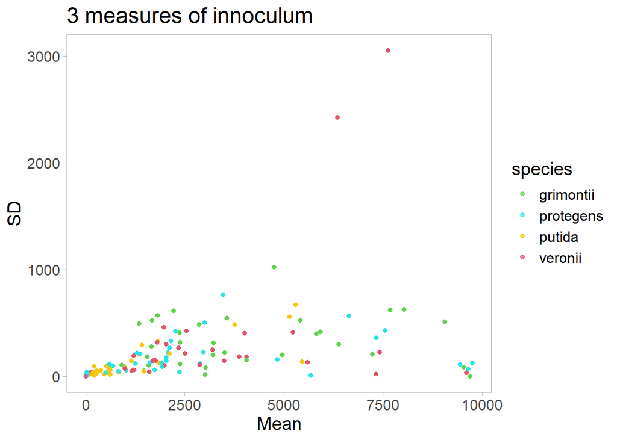

```r
# here's some plots to summarize how much variation there is between measurements of the same inocula
plotting_mean.innoc <- mean.innoc %>% pivot_longer(cols = Mean_putida:SD_veronii,
                                                   names_to = c(".value", "species"),
                                                   names_sep = "_") %>%
                          filter(Incubator != "H1") # the same innoculum was used for 2 treatments on 24-07-08. Remove this redundancy for plotting
ggplot(plotting_mean.innoc,
       aes(x=Mean, y=SD, colour=species)) +
  geom_point(alpha=0.7) +
  scale_colour_manual(values=species_4pal_alphabetical) +
  labs(title="3 measures of innoculum")
```

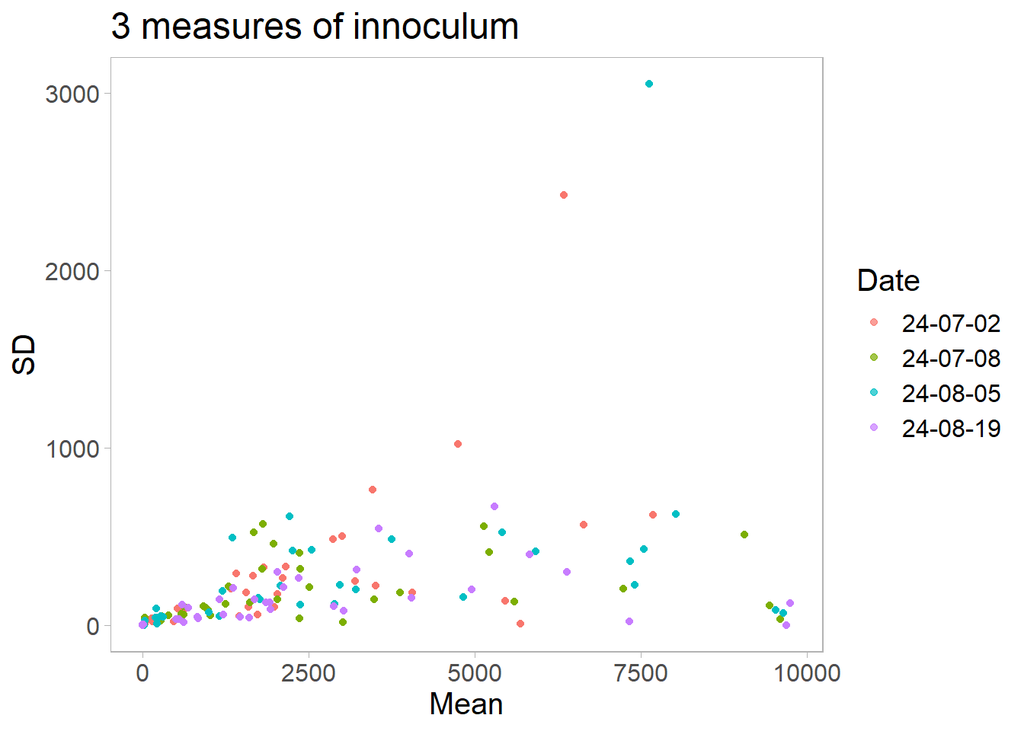

```r
ggplot(plotting_mean.innoc,
       aes(x=Mean, y=SD, colour=Date)) +
  geom_point(alpha=0.7) +
  labs(title="3 measures of innoculum")
```

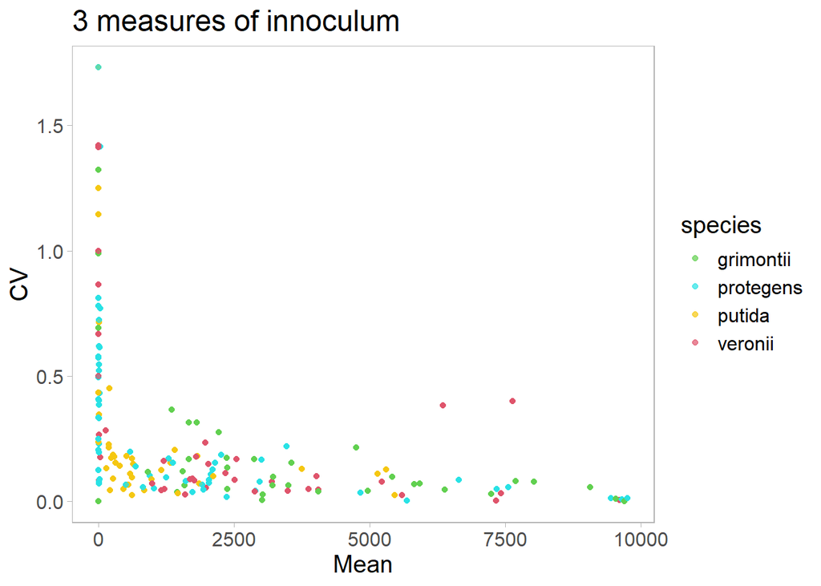

```r
ggplot(plotting_mean.innoc %>% mutate(CV = SD/Mean),
       aes(x=Mean, y=CV, colour=species)) +
  geom_point(alpha=0.7) +
  scale_colour_manual(values=species_4pal_alphabetical) +
  labs(title="3 measures of innoculum")
```

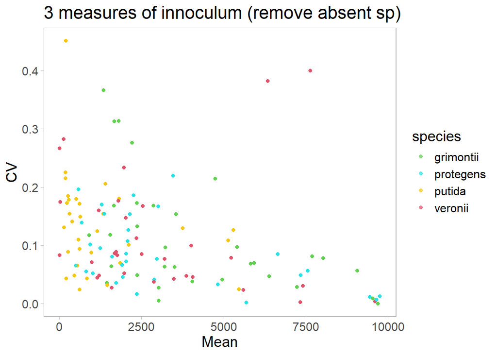

```r
# due to false positive counts,
# the CV blows up when I am counting species that are not actually in that sample

ggplot(plotting_mean.innoc %>% filter((putida == 1 & species == "putida") |
                                      (protegens == 1 & species == "protegens") |
                                      (grimontii == 1 & species == "grimontii") |
                                      (veronii == 1 & species == "veronii")) %>%
            mutate(CV = SD/Mean),
       aes(x=Mean, y=CV, colour=species)) +
  geom_point(alpha=0.7) +
  scale_colour_manual(values=species_4pal_alphabetical) +
  labs(title="3 measures of innoculum (remove absent sp)")
```

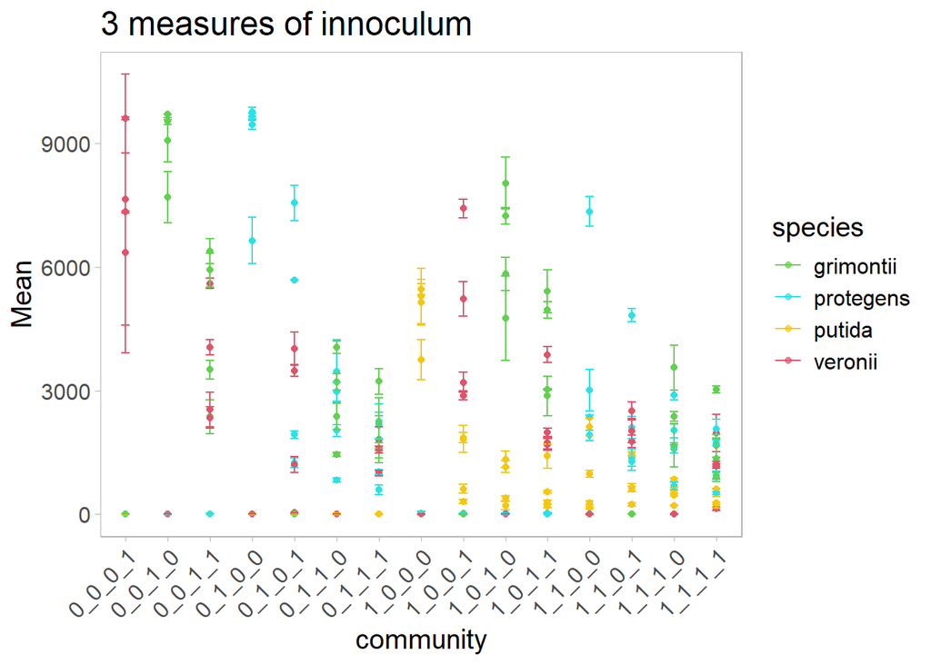

```r
ggplot(plotting_mean.innoc %>% unite("community", putida:veronii),
       aes(x=community, y=Mean, colour=species)) +
  geom_point(alpha=0.7) +
  geom_errorbar(aes(ymin=Mean-SD, ymax=Mean+SD), width=.2) +
  scale_colour_manual(values=species_4pal_alphabetical) +
  theme(axis.text.x = element_text(angle = 45, vjust = 1, hjust=1)) +
  labs(title="3 measures of innoculum")
```

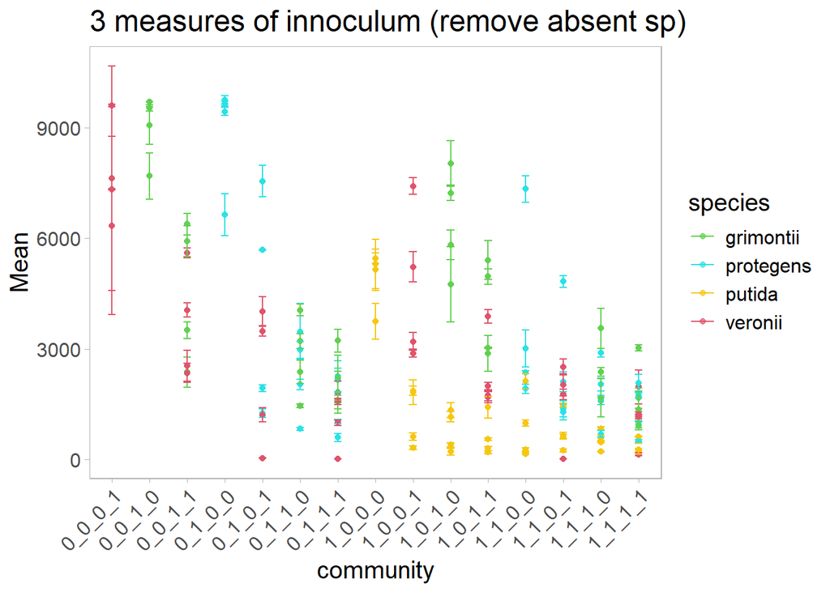

```r
ggplot(plotting_mean.innoc %>% filter((putida == 1 & species == "putida") |
                                      (protegens == 1 & species == "protegens") |
                                      (grimontii == 1 & species == "grimontii") |
                                      (veronii == 1 & species == "veronii")) %>%
            unite("community", putida:veronii),
       aes(x=community, y=Mean, colour=species)) +
  geom_point(alpha=0.7) +
  geom_errorbar(aes(ymin=Mean-SD, ymax=Mean+SD), width=.2) +
  scale_colour_manual(values=species_4pal_alphabetical) +
  theme(axis.text.x = element_text(angle = 45, vjust = 1, hjust=1)) +
  labs(title="3 measures of innoculum (remove absent sp)")
```

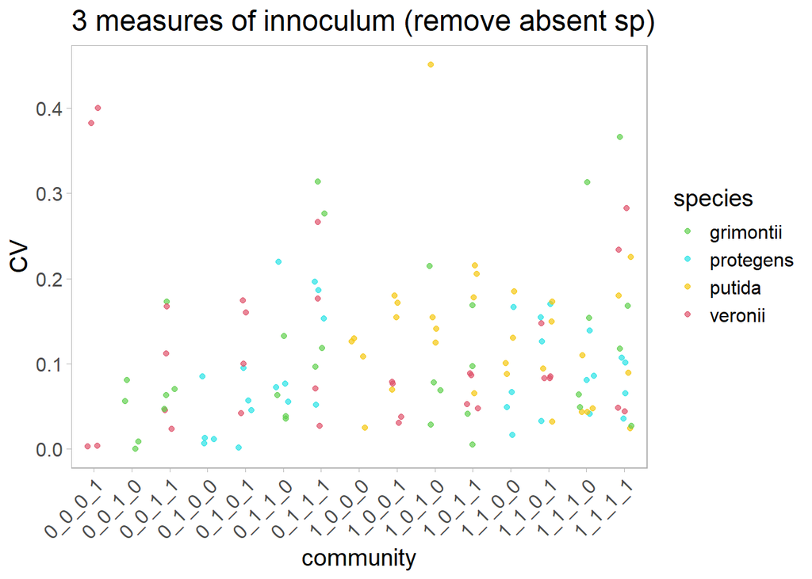

```r
ggplot(plotting_mean.innoc %>% ungroup() %>%
              select(-uniqID, -OD_well) %>% distinct() %>%
                              filter((putida == 1 & species == "putida") |
                                      (protegens == 1 & species == "protegens") |
                                      (grimontii == 1 & species == "grimontii") |
                                      (veronii == 1 & species == "veronii")) %>%
            unite("community", putida:veronii) %>% mutate(CV = SD/Mean),
       aes(x=community, y=CV, colour=species)) +
  geom_jitter(width=0.2, alpha=0.7) +
  scale_colour_manual(values=species_4pal_alphabetical) +
  theme(axis.text.x = element_text(angle = 45, vjust = 1, hjust=1)) +
  labs(title="3 measures of innoculum (remove absent sp)")
```

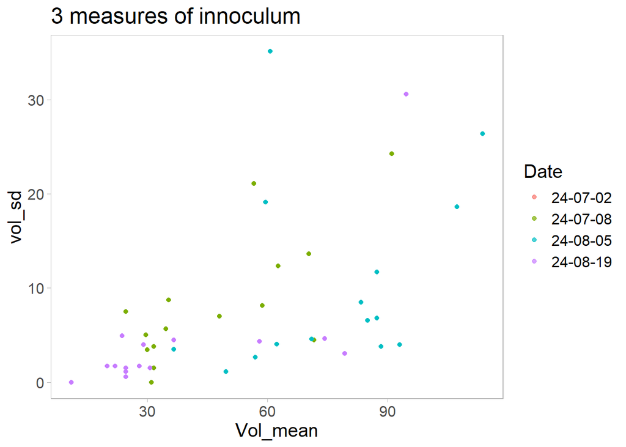

```r
# I have no idea what I would do with this info about sample volume, but here it is:
  # There's no values for 24-07-02 because I accidentally forgot to save the .apx file (this is before I realized that volume is not saved in the .acs files)
ggplot(plotting_mean.innoc,
       aes(x=Vol_mean, y=vol_sd, colour=Date)) +
  geom_point(alpha=0.7) +
  labs(title="3 measures of innoculum")
```

```r
# finally, we can add the mean counts for the Innoc to the whole data
annotated.rawdata <- mean.innoc %>% select(-SD_putida, -SD_protegens, -SD_grimontii, -SD_veronii, -vol_sd) %>%
                      rename(Count_putida=Mean_putida, Count_protegens=Mean_protegens, Count_grimontii=Mean_grimontii, Count_veronii=Mean_veronii, Volume=Vol_mean)
annotated.rawdata <- rbind(annotated.rawdata, annot.days)

# cleanup
rm(annot.days, annot.innoc, plotting_mean.innoc)
```

## Misclassification rate: estimated from innocula (Day 0)

I define the misclassification rate as $\frac{\text{false positive events}}{\text{total events across all fluorescences}}$. In other words, I am counting the number of events in the gate(s) where I know there should be zero then dividing by the total number of fluorescent events in that well. To estimate the misclassification rate, I use the data from Day 0.

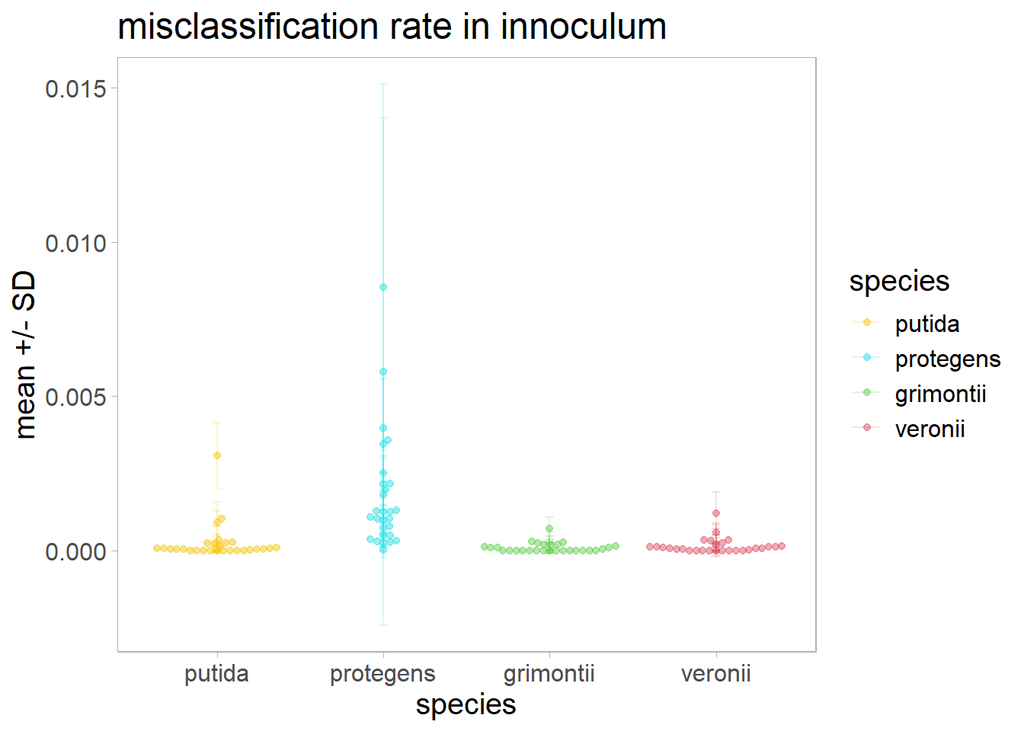

```r
# use Day0 innoculum measurements for a first pass at estimating the misclassification rate
# i.e., the rate of falsely classifying as species A when I know for certain that species A is not present in my sample
misclass.innoc <- mean.innoc %>% mutate(Total_counts = Mean_putida + Mean_protegens + Mean_grimontii + Mean_veronii) %>% # get total for each sample
                    ungroup() %>% select(-uniqID, -OD_well) %>% distinct() %>%   # remove any redundant data
                        # put each species count in its own row in the column called mean (instead of having a column for each species)
                          pivot_longer(cols = Mean_putida:SD_veronii,
                                                   names_to = c(".value", "species"),
                                                   names_sep = "_") %>%
                            filter(Incubator != "H1") %>% # remove the redundant data
                              # keep just the instances where we know for sure that this species was NOT present
                                filter((putida == 0 & species == "putida") |
                                      (protegens == 0 & species == "protegens") |
                                      (grimontii == 0 & species == "grimontii") |
                                      (veronii == 0 & species == "veronii")) %>%
                                  # misclassification rate is the number of events / total counts
                                   mutate(mean_rate = Mean/Total_counts,
                                          sd_rate = SD/Total_counts)

# re-order the species from fast to slow for better plotting
misclass.innoc$species <- factor(misclass.innoc$species,
                                 levels = c("putida", "protegens", "grimontii", "veronii"))

ggplot(misclass.innoc, aes(x=species, y=mean_rate, colour=species)) +
  geom_beeswarm(alpha=0.5) +
  geom_errorbar(aes(ymin=mean_rate-sd_rate, ymax=mean_rate+sd_rate), width=.05, alpha=0.2) +
  scale_colour_manual(values=species_4pal_speed) +
  labs(title="misclassification rate in innoculum", y="mean +/- SD")
```

```r
max(misclass.innoc$mean_rate)
```

```
## [1] 0.008537981
```

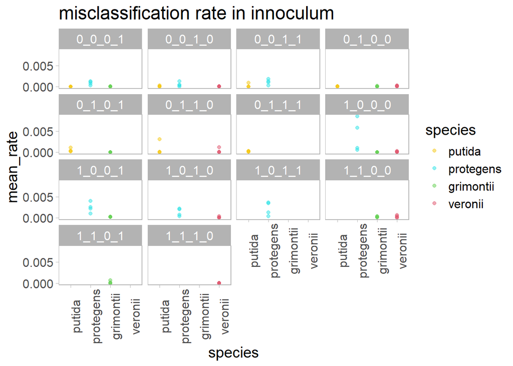

```r
ggplot(misclass.innoc %>% unite("community", putida:veronii),
       aes(x=species, y=mean_rate, colour=species)) +
  facet_wrap(vars(community)) +
  geom_point(alpha=0.5) +
  scale_y_continuous(breaks = c(0, 0.005, 0.01)) +
  scale_colour_manual(values=species_4pal_speed) +
  theme(axis.text.x = element_text(angle = 90)) +
  labs(title="misclassification rate in innoculum")
```

```r
# summarize the mean and max misclassification rates observed for each species
misclass.innoc %>% group_by(species) %>% summarise(mean_misclass = mean(mean_rate),
                                                   max_misclass = max(mean_rate))
```

| species | mean_misclass | max_misclass |
| --- | --- | --- |
| putida | 2.561947e-04 | 0.0030857229 |
| protegens | 1.761275e-03 | 0.0085379808 |
| grimontii | 9.966175e-05 | 0.0007235017 |
| veronii | 1.583103e-04 | 0.0012041845 |

```r
# clean-up
rm(misclass.innoc, mean.innoc)
```

From here we can clearly see that the misclassification rate can be as bad as 1% and that it depends on the species. Protegens is the most likely to be misclassified and, from the plot of all possible community combinations, we see that the problem seems to be that putida cells are being misclassified as belonging to protegens.

But I know that this rate of misclassification also depends on environmental conditions. So I don’t think it makes sense to correct the data using the exact values given above. The more cautious approach would be to treat with caution any counts that are less than 1%.

# Data Processing

Here we make decisions about which data to keep and which to toss.

## Minimum Number of Events

I need to set a threshold for the minimum number of fluorescent events observed in a well in order for me to decide that the well is not trustworthy.

Remember that I set the stopping conditions for 10 000 events in the cell gate OR until it reaches the end of the sample (which seems to be 146uL). Let’s rather arbitrarily set the minimum total events in the well at 51 and see what happens with that.

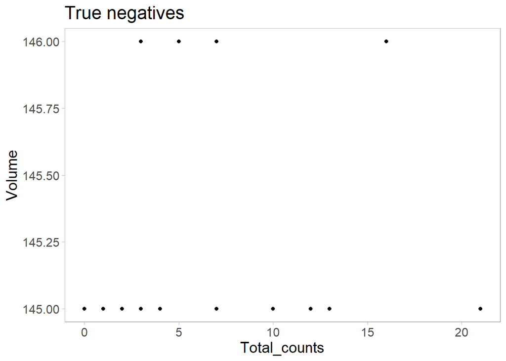

```r
annotated.rawdata <- annotated.rawdata %>% mutate(Total_counts = Count_putida + Count_protegens + Count_grimontii + Count_veronii) %>%
                                           mutate(Total_density = Total_counts/Volume)

# plot the counts and volume for true negative wells
ggplot(annotated.rawdata %>% filter(CommRich==0, !is.na(Total_counts)),
       aes(x=Total_counts, y=Volume)) +
  geom_point() +
  labs(title="True negatives")
```

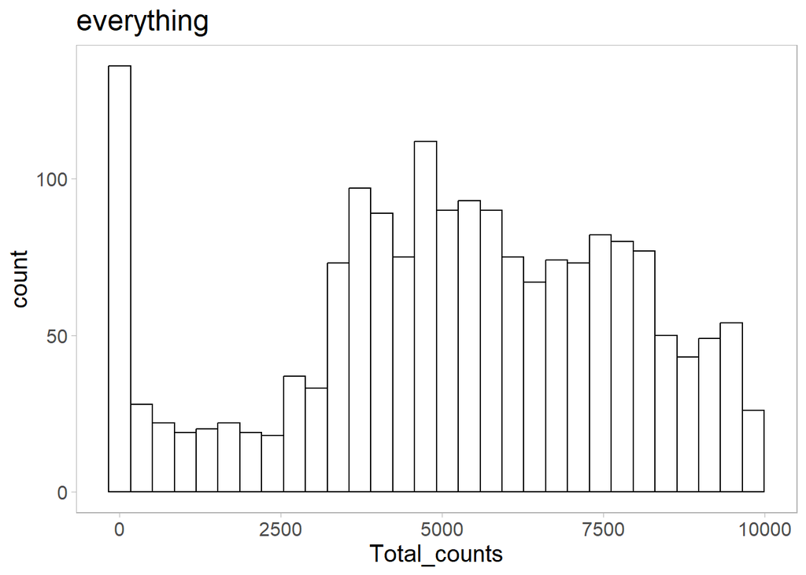

```r
# plot the total counts as a histogram just to see what the dispersal is like
ggplot(annotated.rawdata, aes(x=Total_counts)) +
  geom_histogram(colour="black", fill="white") +
  labs(title="everything")
```

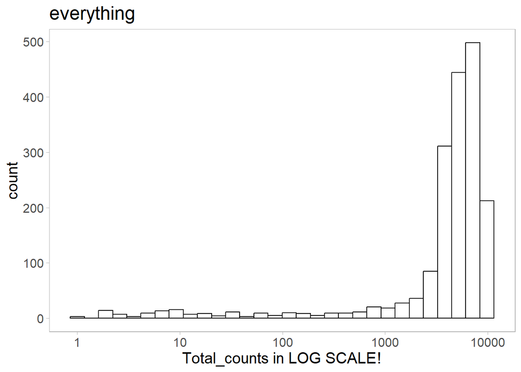

```r
ggplot(annotated.rawdata, aes(x=Total_counts)) +
  geom_histogram(colour="black", fill="white") +
  scale_x_log10() +
  labs(x="Total_counts in LOG SCALE!", title="everything")
```

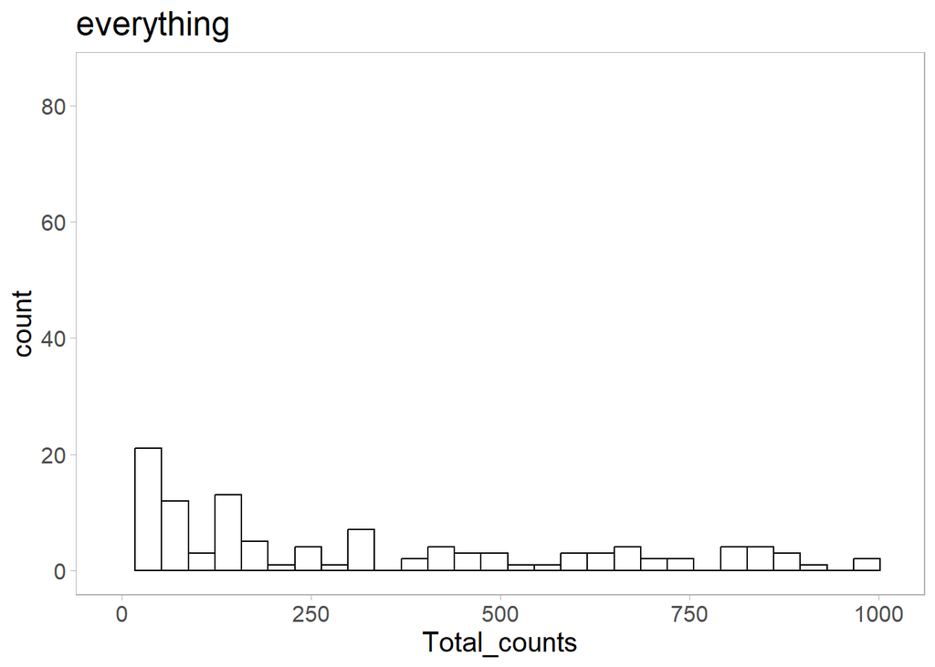

```r
ggplot(annotated.rawdata, aes(x=Total_counts)) +
  geom_histogram(colour="black", fill="white") +
  scale_x_continuous(limits = c(-10,1010)) +
  labs(title="everything")
```

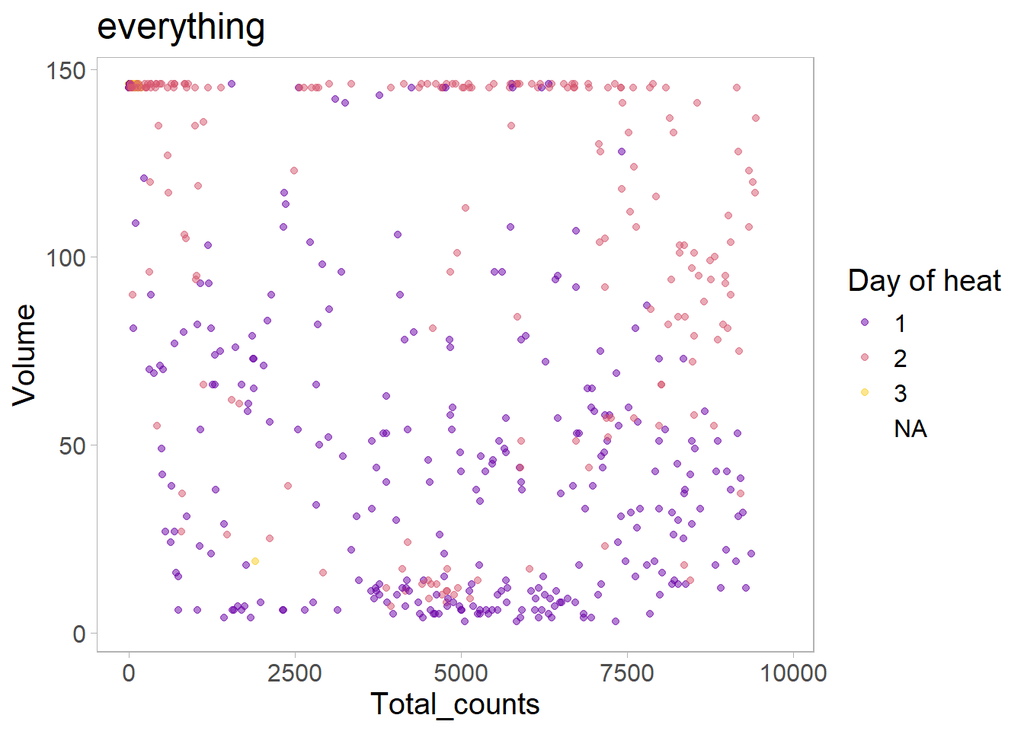

```r
# then plot the total counts against the volume because we expect these very low counts should be associated with the highest volumes
ggplot(annotated.rawdata, aes(x=Total_counts, y=Volume, colour=as.factor(Heat_Day))) +
  geom_point(alpha=0.5) +
  scale_colour_viridis_d(option = "plasma", begin=0.2, end = 0.9) +
  labs(colour="Day of heat") +
  labs(title="everything")
```

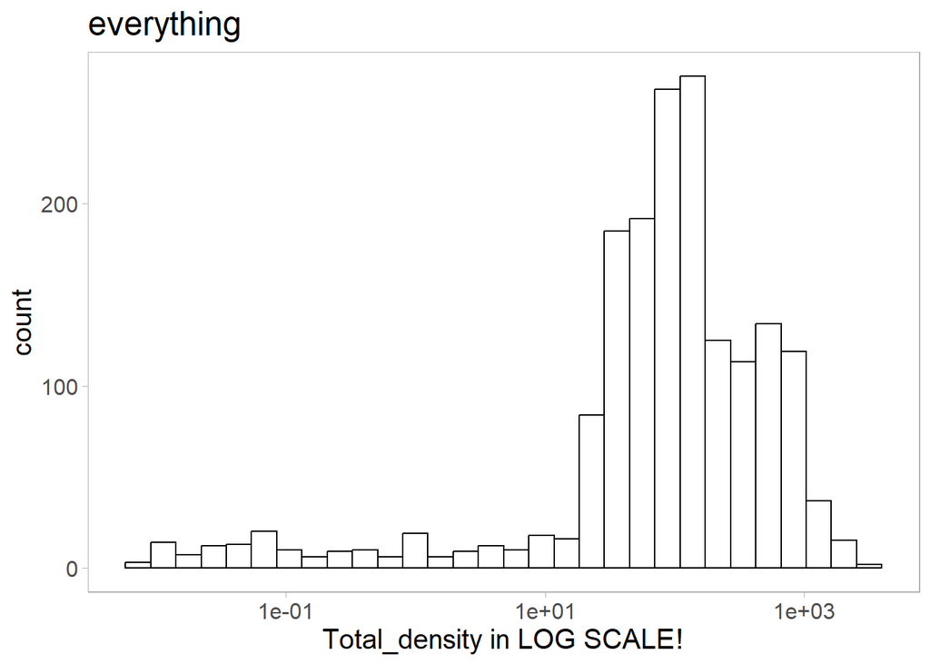

```r
# okay, let's just see a histogram of the total cell density
ggplot(annotated.rawdata, aes(x=Total_density)) +
  geom_histogram(colour="black", fill="white") +
  scale_x_log10() +
  labs(x="Total_density in LOG SCALE!") +
  labs(title="everything")
```

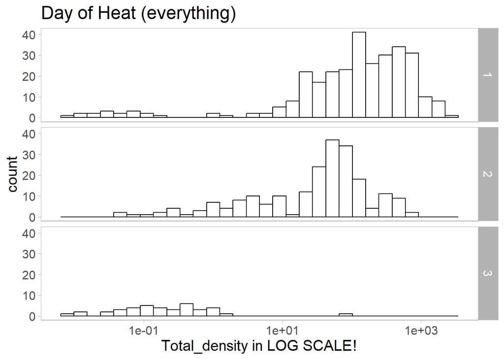

```r
ggplot(annotated.rawdata %>% filter(!is.na(Heat_Day)),
       aes(x=Total_density)) +
  facet_grid(rows = vars(Heat_Day)) +
  geom_histogram(colour="black", fill="white") +
  scale_x_log10() +
  labs(x="Total_density in LOG SCALE!", title="Day of Heat (everything)")
```

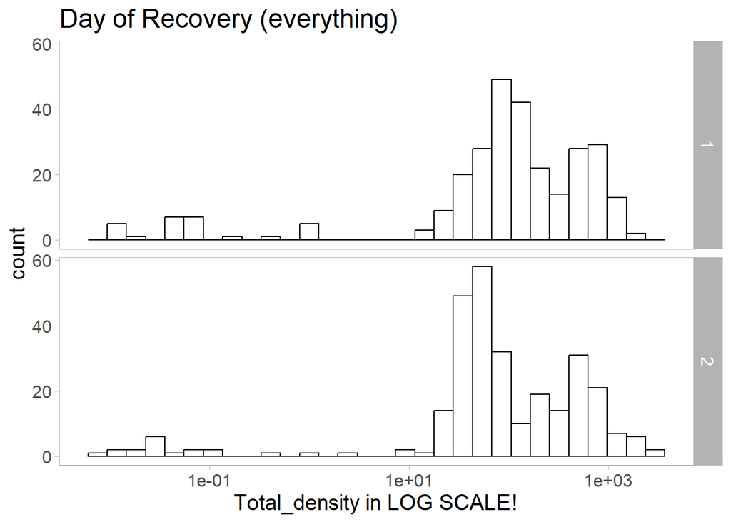

```r
ggplot(annotated.rawdata %>% filter(!is.na(Recov_Day)),
       aes(x=Total_density)) +
  facet_grid(rows = vars(Recov_Day)) +
  geom_histogram(colour="black", fill="white") +
  scale_x_log10() +
  labs(x="Total_density in LOG SCALE!", title="Day of Recovery (everything)")
```

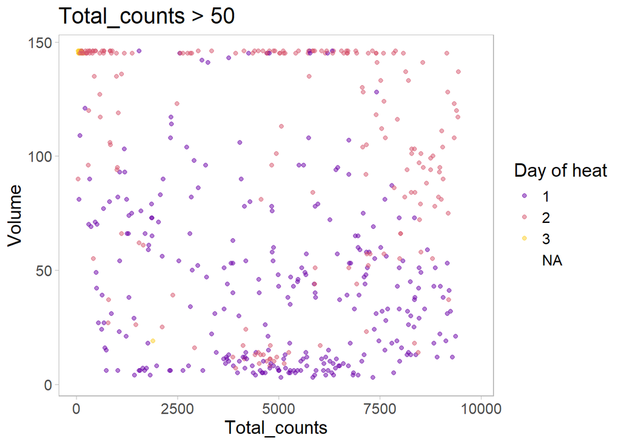

```r
### check what these graphs look like when I exclude wells where Total_counts < 51
ggplot(annotated.rawdata %>% filter(Total_counts > 50),
       aes(x=Total_counts, y=Volume, colour=as.factor(Heat_Day))) +
  geom_point(alpha=0.5) +
  scale_colour_viridis_d(option = "plasma", begin=0.2, end = 0.9) +
  labs(colour="Day of heat") +
  labs(title="Total_counts > 50")
```

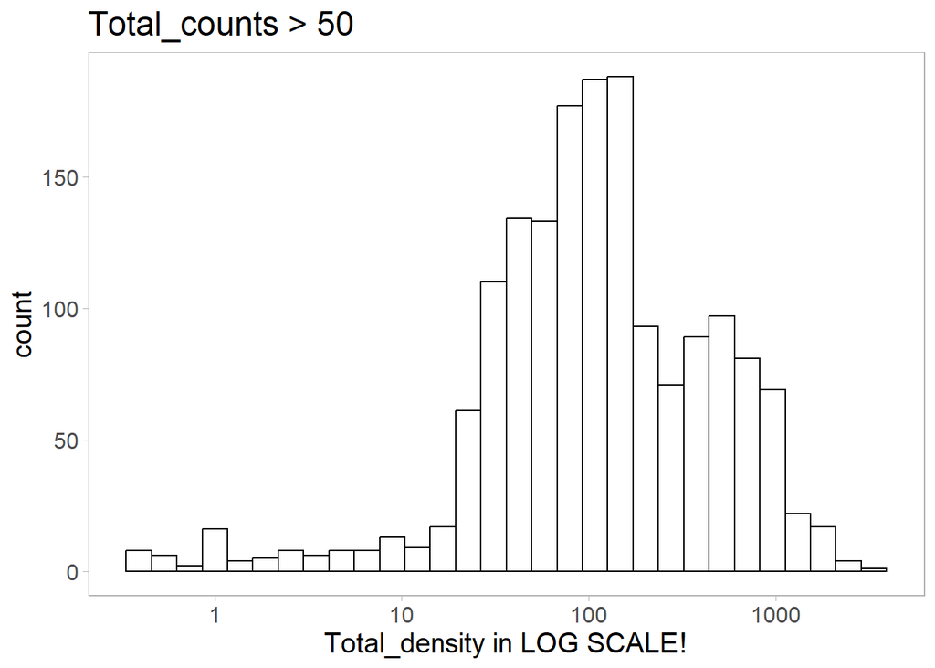

```r
ggplot(annotated.rawdata %>% filter(Total_counts > 50),
       aes(x=Total_density)) +
  geom_histogram(colour="black", fill="white") +
  scale_x_log10() +
  labs(x="Total_density in LOG SCALE!") +
  labs(title="Total_counts > 50")
```

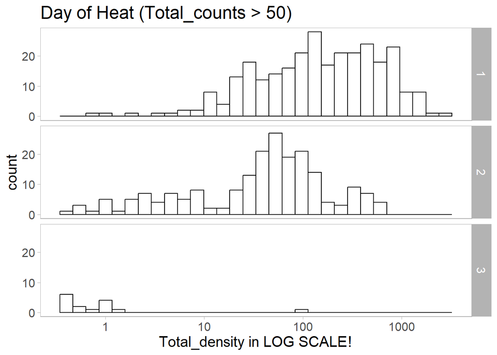

```r
ggplot(annotated.rawdata %>% filter(Total_counts > 50, !is.na(Heat_Day)),
       aes(x=Total_density)) +
  facet_grid(rows = vars(Heat_Day)) +
  geom_histogram(colour="black", fill="white") +
  scale_x_log10() +
  labs(x="Total_density in LOG SCALE!", title="Day of Heat (Total_counts > 50)")
```

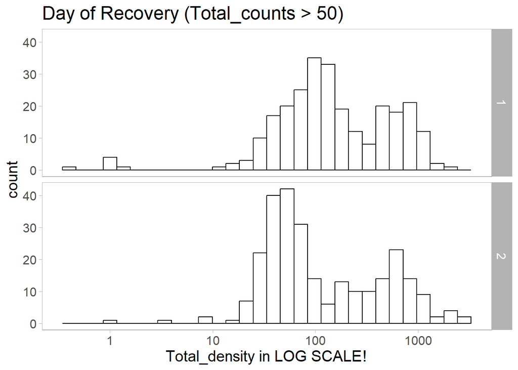

```r
ggplot(annotated.rawdata %>% filter(Total_counts > 50, !is.na(Recov_Day)),
       aes(x=Total_density)) +
  facet_grid(rows = vars(Recov_Day)) +
  geom_histogram(colour="black", fill="white") +
  scale_x_log10() +
  labs(x="Total_density in LOG SCALE!", title="Day of Recovery (Total_counts > 50)")
```

```r
#######
# set threshold of > 50 events in total
#######
# copy everything EXCEPT BLANK WELLS to new variable
the.data <- annotated.rawdata %>% filter(CommRich != 0)

# summarize some information about the data points that I'm about to exclude
the.data %>% filter(Total_counts < 51) %>% ungroup() %>% select(uniqID, Heat, Day, Heat_Day, Recov_Day, CommRich, Volume, Total_counts) %>% summary()
```

```
##     uniqID               Heat            Day           Heat_Day
##  Length:87          Min.   : 0.00   Min.   :2.000   Min.   :2.00
##  Class :character   1st Qu.:48.00   1st Qu.:3.000   1st Qu.:2.75
##  Mode  :character   Median :48.00   Median :4.000   Median :3.00
##                     Mean   :41.66   Mean   :3.621   Mean   :2.75
##                     3rd Qu.:48.00   3rd Qu.:4.000   3rd Qu.:3.00
##                     Max.   :48.00   Max.   :5.000   Max.   :3.00
##                                                     NA's   :47
##    Recov_Day        CommRich         Volume       Total_counts
##  Min.   :1.000   Min.   :1.000   Min.   :145.0   Min.   : 0.00
##  1st Qu.:1.000   1st Qu.:1.000   1st Qu.:145.0   1st Qu.: 2.50
##  Median :1.000   Median :2.000   Median :145.0   Median : 7.00
##  Mean   :1.462   Mean   :1.782   Mean   :145.4   Mean   :10.72
##  3rd Qu.:2.000   3rd Qu.:2.000   3rd Qu.:146.0   3rd Qu.:15.00
##  Max.   :2.000   Max.   :4.000   Max.   :146.0   Max.   :50.00
##  NA's   :48
```

```r
# exclude from analysis all non-blanks rows where Total_counts < 51
the.data$CommRich[which(the.data$Total_counts < 51)] <- NA

# put the blank data back with the whole dataset
the.data <- rbind(the.data,
                  annotated.rawdata %>% filter(CommRich == 0))

# replace the data with NA values for all rows where Total_counts < 51
    # this includes both the excluded unreliable data as well as the true blanks flow data
the.data$Count_putida[which(the.data$Total_counts < 51)] <- NA
the.data$Count_protegens[which(the.data$Total_counts < 51)] <- NA
the.data$Count_grimontii[which(the.data$Total_counts < 51)] <- NA
the.data$Count_veronii[which(the.data$Total_counts < 51)] <- NA
the.data$Total_density[which(the.data$Total_counts < 51)] <- NA
the.data$Total_counts[which(the.data$Total_counts < 51)] <- NA

# clean-up
rm(annotated.rawdata)
```

I have re-assigned all wells that had less than 51 total fluorescent events as NA values. This was a total of 87 wells.

Note that I’ve also removed any flow cytometry data from the true negative wells. This was 17 wells.

```r
# calculate densities and relative abundances for each species
the.data <- the.data %>% mutate(Conc_putida = Count_putida/Volume,
                                Conc_protegens = Count_protegens/Volume,
                                Conc_grimontii = Count_grimontii/Volume,
                                Conc_veronii = Count_veronii/Volume,
                                relDen_putida = Count_putida/Total_counts,
                                relDen_protegens = Count_protegens/Total_counts,
                                relDen_grimontii = Count_grimontii/Total_counts,
                                relDen_veronii = Count_veronii/Total_counts) #%>%
              #select(-Total_counts)

# sanity check that the relative densities are always adding up to 1
check <- the.data %>% mutate(sum_relDen = relDen_putida + relDen_protegens + relDen_grimontii + relDen_veronii) %>%
            # for convenience, remove the 87 NA values
            drop_na(Total_counts)
all.equal(check$sum_relDen, rep(1, nrow(check))) %>% # use all.equal() as there seem values very close to 1 but not exactly equal to 1
  stopifnot()

rm(check)
```

I have calculated the relative densities and made sure that all relative densities add up to 1.